# Homework 10 Template

Author

The goal of this week’s homework is to practice doing model validation within the tidymodels family of packages. For our analysis, I have created a dataset related to flight delays coming into Hartford in the year 2008.

These new data are provided on HuskyCT as airline_BDL.csv.

```r
library(tidyverse)
library(tidymodels)
theme_set(theme_bw())
tidymodels_prefer()

airline_BDL <- read_csv("airline_BDL.csv")
airline_BDL <- airline_BDL |>
  mutate(arr_delay_over_30 = factor(arr_delay_over_30))

airline_BDL |>
  glimpse()
```

```
Rows: 10,144
Columns: 8
$ arr_delay_over_30    <fct> TRUE, FALSE, TRUE, FALSE, FALSE, TRUE, TRUE, FALS…
$ distance             <dbl> 2298, 1050, 1050, 1050, 777, 777, 1111, 1111, 852…
$ origin               <chr> "LAS", "MCO", "MCO", "MCO", "MDW", "MDW", "TPA", …
$ month                <chr> "January", "January", "January", "January", "Janu…
$ day_of_week          <chr> "Thursday", "Thursday", "Thursday", "Thursday", "…
$ dep_delay            <dbl> 59, 3, 27, 4, 30, 33, 28, 23, 21, 3, -3, -3, 11, …
$ scheduled_dep_hour   <dbl> 16, 16, 10, 7, 19, 13, 10, 15, 18, 19, 20, 13, 21…
$ scheduled_dep_minute <dbl> 40, 45, 30, 25, 0, 50, 45, 25, 35, 55, 30, 35, 25…
```

Each of the 10144 rows in this dataset corresponds to a different flight into Bradley airport in 2008. There 8 columns (variables) described as follows:

- arr_delay_over_30: a logical variable indicating whether or not the flight’s actual arrival time was 30 or more minutes later than its scheduled arrival time. This variable will be our response variable
- distance: the distance (in miles) the flight had to travel
- origin: the airport of origin
- day_of_week: the day of the week that the flight departed
- departure_delay: the number of minutes between the flight’s scheduled departure time and actual departure time (negative means the flight departed early)
- the hour (1 means 1 am, 23 means 11 pm, etc.) of the flight’s scheduled departure.
- the minute of the flights scheduled departure

Our goal is to create a model that predicts whether or not a flight’s arrival will be delayed 30 or more minutes based on the remaining variables.

# Problem 1 [23 Points Total]

We will define four candidate models that we will be comparing. Please develop a workflow for each model that is described.

## Part A [7 Points]

A logistic regression, fit using maximum likelihood, with arr_delay_over_30 as the response and all other variables as explanatory variables.

The preprocessor should be defined using a recipe. The recipe should normalize all the numeric predictors. Moreover, it should replace any origin city that occurs in less than 1 percent of the data with an “other” category

Call this workflow workflow_A.

```r
# YOUR CODE HERE

library(tidymodels)
library(workflows)

# Define the logistic regression model
logistic_reg_model <- logistic_reg() |>
  set_engine("glm", family = "binomial") |>
  set_mode("classification")

bdl_workflow_1 <- workflow() |>
  add_model(logistic_reg_model) |>
  add_formula(Gender ~ .)

# Define the recipe
recipe_arr_delay <- recipe(arr_delay_over_30 ~ ., data = airline_BDL) |>
  step_normalize(all_numeric_predictors(), -all_outcomes()) |>
  step_other(origin, threshold = 0.01, other = "other") |>
  step_dummy(all_nominal(), -all_outcomes())

# Define workflow_A
workflow_A <- workflow() |>
  add_model(logistic_reg_model) |>
  add_recipe(recipe_arr_delay)
```

## Part B [5 Points]

A logistic regression, fit using the lasso with a penalty = 0.1, with arr_delay_over_30 as the response and all other variables as explanatory variables. Use the same recipe as in A. Call this workflow workflow_B.

```r
# YOUR CODE HERE

# Define the logistic regression model with lasso penalty
logistic_lasso_model <- logistic_reg(penalty = 0.1) |>
  set_engine("glmnet") |>
  set_mode("classification")

# Define workflow_B with the same recipe as workflow_A
workflow_B <- workflow() |>
  add_model(logistic_lasso_model) |>
  add_recipe(recipe_arr_delay)
```

## Part C [5 Points]

A k-nearest neighbors model, fit using k = 10, with arr_delay_over_30 as the response and all other variables as explanatory variables. Use the same recipe as in A. Call this workflow workflow_C.

```r
# YOUR CODE HERE
library(kknn)

# Define the KNN model
knn_model <- nearest_neighbor(neighbors = 10) |>
  set_engine("kknn") |>
  set_mode("classification")

# Define workflow_C with the same recipe as workflow_A
workflow_C <- workflow() |>
  add_model(knn_model) |>
  add_recipe(recipe_arr_delay)
```

## Part D [5 Points]

A random forest model, fit using ranger, with arr_delay_over_30 as the response and all other variables as explanatory variables. Use the same recipe as in A. Call this workflow workflow_D.

```r
# YOUR CODE HERE

# Define the random forest model using the ranger engine
rf_model <- rand_forest() |>
  set_engine("ranger") |>
  set_mode("classification")

# Define workflow_D with the same recipe as workflow_A
workflow_D <- workflow() |>
  add_model(rf_model) |>
  add_recipe(recipe_arr_delay)
```

# Problem 2 [25 Points Total]

Now, we will practice different data splitting strategies.

## Part A [5 Points]

First, split the data into a testing and training set with 70 percent of the data being used for training, 30 percent being used for test, and no stratification.

```r
# YOUR CODE HERE

bdl_split <- initial_split(airline_BDL,
                              prop = 0.70)
bdl_train <- bdl_split |>
  training()

bdl_test <- bdl_split |>
  testing()
```

## Part B [5 Points]

From the training set, create a variable of class rset called val_set that contains test-validation split where the validation set contains 20 percent of the data in the training set.

```r
# YOUR CODE HERE
val_set <- validation_split(bdl_train,
                            prop = 0.8)
val_set |>
  class()
```

```
[1] "validation_split" "rset"             "tbl_df"           "tbl"
[5] "data.frame"
```

## Part C [5 Points]

From the training set, create a variable of class rset called vfold_set that contains a 5-fold cross validation split.

```r
# YOUR CODE HERE

vfold_set <- bdl_train |>
  vfold_cv(v = 5)
```

## Part D [5 Points]

From the training set, create a variable of class rset called mc_set that contains 10 random splits of the data.

```r
# YOUR CODE HERE

mc_set <- bdl_train |>
  mc_cv(times = 10)
```

## Part E [5 Points]

From the training set, create a variable of class rset called bootstrap_set that contains 10 bootstrap random splits of the data.

```r
# YOUR CODE HERE
bootstrap_set <- bdl_train  |>
  bootstraps(times = 10)
```

# Problem 3 [37 Points Total]

We are now going to compare the performance of each in the workflows in Problem 1 using each of the validation strategies from Problem 2.

## Part A [8 Points]

Using this metric set and a re-substitution strategy, compare the performance of the four workflows (workflow_A, workflow_B, workflow_C, and workflow_D) defined in Problem 1. Use area under the ROC curve as the comparison metric.

```r
# YOUR CODE HERE

workflow_names <- c("workflow_A",
                    "workflow_B",
                    "workflow_C",
                    "workflow_D")

workflow_objects <- list(workflow_A,
                         workflow_B,
                         workflow_C,
                         workflow_D)

workflows_tbl <- tibble(work_names = workflow_names,
                        work_objects = workflow_objects)
```

```r
workflows_tbl <-  workflows_tbl |>
  rowwise() |>
  mutate(fits = list(fit(work_objects,
                         bdl_train)))
```

```r
workflows_resub <- workflows_tbl |>
  mutate(pred_class = list(predict(fits,
                                    bdl_train,
                                    type = "class"))) |>
  mutate(pred_prob = list(predict(fits,
                                  bdl_train,
                                  type = "prob")))


predictions_resub  <- workflows_resub |>
  select(work_names,
         pred_class,
         pred_prob) |>
  unnest(cols = c(pred_class, pred_prob)) |>
  cbind(delay = bdl_train |>
          pull(arr_delay_over_30))
```

Which workflow performed best according to this metric?

```r
# YOUR CODE HERE
predictions_resub |>
  group_by(work_names) |>
  roc_auc(truth = delay,
           .pred_FALSE)
```

```
# A tibble: 4 × 4
  work_names .metric .estimator .estimate
  <chr>      <chr>   <chr>          <dbl>
1 workflow_A roc_auc binary         0.962
2 workflow_B roc_auc binary         0.953
3 workflow_C roc_auc binary         0.997
4 workflow_D roc_auc binary         0.995
```

## Part B [7 Points]

Define a metric set consisting exclusively of the area under the ROC curve.

```r
# YOUR CODE HERE

bdl_metric_set <- metric_set(roc_auc)
```

Use this metric set and the validation set from Problem 2B to compare the performance of the four workflows (workflow_A, workflow_B, workflow_C, and workflow_D) defined in Problem 1.

```r
# YOUR CODE HERE
workflows_val <- workflows_tbl |>
  mutate(fits = list(fit_resamples(work_objects,
                                   val_set,
                                   metrics = bdl_metric_set))) |>
  mutate(metrics = list(collect_metrics(fits)))
```

```
→ A | warning: glm.fit: fitted probabilities numerically 0 or 1 occurred
```

```
There were issues with some computations   A: x1
There were issues with some computations   A: x1
```

Which workflow performed best according to this metric?

```r
# YOUR CODE HERE
workflows_val |>
  select(c(work_names,
           metrics)) |>
  unnest(metrics) |>
  arrange(.metric)
```

```
# A tibble: 4 × 7
  work_names .metric .estimator  mean     n std_err .config
  <chr>      <chr>   <chr>      <dbl> <int>   <dbl> <chr>
1 workflow_A roc_auc binary     0.949     1      NA Preprocessor1_Model1
2 workflow_B roc_auc binary     0.946     1      NA Preprocessor1_Model1
3 workflow_C roc_auc binary     0.826     1      NA Preprocessor1_Model1
4 workflow_D roc_auc binary     0.944     1      NA Preprocessor1_Model1
```

workflow_A, or the logistic regression model, performed best according to this metric.

## Part C [7 Points]

Use the same metric set from above and vfold_set from Problem 2C to compare the performance of the four workflows (workflow_A, workflow_B, workflow_C, and workflow_D) defined in Problem 1.

```r
# YOUR CODE HERE

workflows_vfold <- workflows_tbl |>
  mutate(fits = list(fit_resamples(work_objects,
                                   vfold_set,
                                   metrics = bdl_metric_set))) |>
  mutate(metrics = list(collect_metrics(fits)))
```

```
→ A | warning: glm.fit: fitted probabilities numerically 0 or 1 occurred
```

```
There were issues with some computations   A: x1
```

```
There were issues with some computations   A: x5
```

Which workflow performed worst according to this metric?

```r
# YOUR CODE HERE

workflows_vfold |>
  select(c(work_names,
           metrics)) |>
  unnest(metrics) |>
  arrange(.metric)
```

```
# A tibble: 4 × 7
  work_names .metric .estimator  mean     n std_err .config
  <chr>      <chr>   <chr>      <dbl> <int>   <dbl> <chr>
1 workflow_A roc_auc binary     0.958     5 0.00455 Preprocessor1_Model1
2 workflow_B roc_auc binary     0.952     5 0.00347 Preprocessor1_Model1
3 workflow_C roc_auc binary     0.813     5 0.00676 Preprocessor1_Model1
4 workflow_D roc_auc binary     0.951     5 0.00526 Preprocessor1_Model1
```

workflow_A, or the logistic regression model, performed best according to this metric.

## Part D [10 Points]

Use the same metric set from above and mc_set from Problem 2D to compare the performance of the four workflows (workflow_A, workflow_B, workflow_C, and workflow_D) defined in Problem 1.

```r
# YOUR CODE HERE

workflows_mc <- workflows_tbl |>
  mutate(fits = list(fit_resamples(work_objects,
                                   mc_set,
                                   metrics = bdl_metric_set))) |>
  mutate(metrics = list(collect_metrics(fits)))
```

```
→ A | warning: glm.fit: fitted probabilities numerically 0 or 1 occurred
```

```
There were issues with some computations   A: x1
```

```
There were issues with some computations   A: x3
```

```
There were issues with some computations   A: x10
```

According to the results, is the difference between the performance of workflow A (logistic regression) and workflow D (random forest) statistically significant?

```r
# YOUR CODE HERE
workflows_mc_res <- workflows_mc |>
  mutate(metrics = list(collect_metrics(fits,
                                        summarize = FALSE)))

workflows_mc_res
```

```
# A tibble: 4 × 4
# Rowwise:
  work_names work_objects fits      metrics
  <chr>      <list>       <list>    <list>
1 workflow_A <workflow>   <rsmp[+]> <tibble [10 × 5]>
2 workflow_B <workflow>   <rsmp[+]> <tibble [10 × 5]>
3 workflow_C <workflow>   <rsmp[+]> <tibble [10 × 5]>
4 workflow_D <workflow>   <rsmp[+]> <tibble [10 × 5]>
```

```r
workflows_mc_results <- workflows_mc_res |>
  select(work_names,
         metrics) |>
  unnest(metrics) |>
  select(work_names,
         id,
         .estimate)

workflows_mc_results_wider <- workflows_mc_results  |>
  pivot_wider(names_from = work_names,
              values_from = .estimate)

workflows_mc_results_wider
```

```
# A tibble: 10 × 5
   id         workflow_A workflow_B workflow_C workflow_D
   <chr>           <dbl>      <dbl>      <dbl>      <dbl>
 1 Resample01      0.964      0.966      0.825      0.954
 2 Resample02      0.951      0.947      0.816      0.949
 3 Resample03      0.966      0.957      0.809      0.950
 4 Resample04      0.961      0.959      0.809      0.955
 5 Resample05      0.955      0.949      0.825      0.960
 6 Resample06      0.951      0.942      0.791      0.942
 7 Resample07      0.945      0.934      0.832      0.947
 8 Resample08      0.961      0.953      0.812      0.958
 9 Resample09      0.955      0.950      0.829      0.952
10 Resample10      0.948      0.943      0.812      0.951
```

```r
t.test(workflows_mc_results_wider$workflow_A,
       workflows_mc_results_wider$workflow_D) |>
  tidy()
```

```
# A tibble: 1 × 10
  estimate estimate1 estimate2 statistic p.value parameter conf.low conf.high
     <dbl>     <dbl>     <dbl>     <dbl>   <dbl>     <dbl>    <dbl>     <dbl>
1  0.00369     0.956     0.952      1.31   0.209      16.8 -0.00227   0.00966
# ℹ 2 more variables: method <chr>, alternative <chr>
```

## Part E [5 Points]

Use the same metric set from above and bootstrap_set from Problem 2E to compare the performance of the four workflows (workflow_A, workflow_B, workflow_C, and workflow_D) defined in Problem 1.

```r
# YOUR CODE HERE

workflows_bs <- workflows_tbl |>
  mutate(fits = list(fit_resamples(work_objects,
                                   bootstrap_set,
                                   metrics = bdl_metric_set))) |>
  mutate(metrics = list(collect_metrics(fits)))
```

```
→ A | warning: glm.fit: fitted probabilities numerically 0 or 1 occurred
```

```
There were issues with some computations   A: x1
```

```
There were issues with some computations   A: x7
```

```
There were issues with some computations   A: x10
```

Which workflow’s performance estimator has the highest standard error?

```r
# YOUR CODE HERE

workflows_bs |>
  select(c(work_names,
           metrics)) |>
  unnest(metrics) |>
  arrange(.metric)
```

```
# A tibble: 4 × 7
  work_names .metric .estimator  mean     n std_err .config
  <chr>      <chr>   <chr>      <dbl> <int>   <dbl> <chr>
1 workflow_A roc_auc binary     0.959    10 0.00223 Preprocessor1_Model1
2 workflow_B roc_auc binary     0.956    10 0.00236 Preprocessor1_Model1
3 workflow_C roc_auc binary     0.786    10 0.00461 Preprocessor1_Model1
4 workflow_D roc_auc binary     0.954    10 0.00231 Preprocessor1_Model1
```

workflow_C, or the KNN model, has the highest standard error.

# Problem 4 [15 Points Total]

## Part A [9 Points]

Create plot with geom_col(position = “dodge”) to compare the estimated predictive performance of all four models based on the different validation strategies discussed above:

- re-substitution,
- a validation set,
- vfold cross validation,
- Monte Carlo cross validation, and
- bootstrap cross validation.

```r
bootstrap <- workflows_bs|>
  select(c(work_names,
           metrics)) |>
  unnest(metrics) |> select(c(work_names, mean))
MC <- workflows_mc|>
  select(c(work_names,
           metrics)) |>
  unnest(metrics) |> select(c(work_names, mean))
resub <- predictions_resub |>
  group_by(work_names) |>
  roc_auc(truth = delay,
           .pred_FALSE) |>
  select(c(work_names, .estimate)) |>
  rename(mean = .estimate)
validation <- workflows_val|>
  select(c(work_names,
           metrics)) |>
  unnest(metrics) |> select(c(work_names, mean))
vfold <- workflows_vfold|>
  select(c(work_names,
           metrics)) |>
  unnest(metrics) |> select(c(work_names, mean))
```

```r
merged_data <- bind_rows(
  mutate(bootstrap, source = "bootstrap"),
  mutate(MC, source = "MC"),
  mutate(resub, source = "resub"),
  mutate(validation, source = "validation"),
  mutate(vfold, source = "vfold")
) |>
  rename(estimate = mean,
         method = source) |>
  mutate(work_names = ifelse(work_names == "workflow_A", "logistic", work_names),
         work_names = ifelse(work_names == "workflow_B", "logistic_lasso", work_names),
         work_names = ifelse(work_names == "workflow_C", "10-nearest-neighbours", work_names),
         work_names = ifelse(work_names == "workflow_D", "random_forest", work_names))

merged_data
```

```
# A tibble: 20 × 3
   work_names            estimate method
   <chr>                    <dbl> <chr>
 1 logistic                 0.959 bootstrap
 2 logistic_lasso           0.956 bootstrap
 3 10-nearest-neighbours    0.786 bootstrap
 4 random_forest            0.954 bootstrap
 5 logistic                 0.956 MC
 6 logistic_lasso           0.950 MC
 7 10-nearest-neighbours    0.816 MC
 8 random_forest            0.952 MC
 9 logistic                 0.962 resub
10 logistic_lasso           0.953 resub
11 10-nearest-neighbours    0.997 resub
12 random_forest            0.995 resub
13 logistic                 0.949 validation
14 logistic_lasso           0.946 validation
15 10-nearest-neighbours    0.826 validation
16 random_forest            0.944 validation
17 logistic                 0.958 vfold
18 logistic_lasso           0.952 vfold
19 10-nearest-neighbours    0.813 vfold
20 random_forest            0.951 vfold
```

```r
# YOUR CODE HERE

theme_set(theme_bw())
library(ggplot2)
```

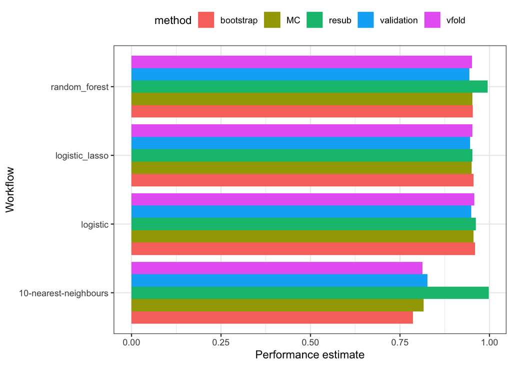

```r
merged_data |>
  ggplot(aes(x = estimate, y = work_names, fill=method)) +
  geom_bar(stat = "identity", position = "dodge") +
  labs(x = "Performance estimate",
       y = "Workflow") +
  theme(legend.position = "top")
```

Comment on the the implications of this figure. Which validation methods seem to mostly agree? Which tend to differ? For workflows do they differ? Why do you think these differences occur?

## Part B [6 Points]

Evaluate the predictive performance on the held-out test data.

```r
# YOUR CODE HERE

workflows_tbl <-  workflows_tbl |>
  rowwise() |>
  mutate(fits = list(fit(work_objects,
                         bdl_train)))
workflows_tbl_predictions <- workflows_tbl |>
  mutate(pred_class = list(predict(fits,
                                   bdl_test,
                                   type = "class"))) |>
  mutate(pred_prob = list(predict(fits,
                                  bdl_test,
                                  type = "prob")))

workflows_tbl_predictions <- workflows_tbl_predictions |>
  mutate(predictions = list(bind_cols(pred_class, pred_prob))) |>
  select(-c(pred_class, pred_prob))
```

```r
predictions_tbl  <- workflows_tbl_predictions |>
  select(work_names,
         predictions) |>
  unnest(cols = c(predictions)) |>
  cbind(delay = bdl_test |>
          pull(arr_delay_over_30))
```

```r
roc_auc_all <- predictions_tbl |>
  group_by(work_names) |>
  roc_auc(truth = delay,
          .pred_TRUE,
          event_level = "second") |>
  mutate(work_names = ifelse(work_names == "workflow_A", "logistic", work_names),
         work_names = ifelse(work_names == "workflow_B", "logistic_lasso", work_names),
         work_names = ifelse(work_names == "workflow_C", "10-nearest-neighbours", work_names),
         work_names = ifelse(work_names == "workflow_D", "random_forest", work_names)) |>
  rename(estimate = .estimate) |>
  mutate(method = NA)

roc_auc_all
```

```
# A tibble: 4 × 5
  work_names            .metric .estimator estimate method
  <chr>                 <chr>   <chr>         <dbl> <lgl>
1 logistic              roc_auc binary        0.968 NA
2 logistic_lasso        roc_auc binary        0.968 NA
3 10-nearest-neighbours roc_auc binary        0.846 NA
4 random_forest         roc_auc binary        0.955 NA
```

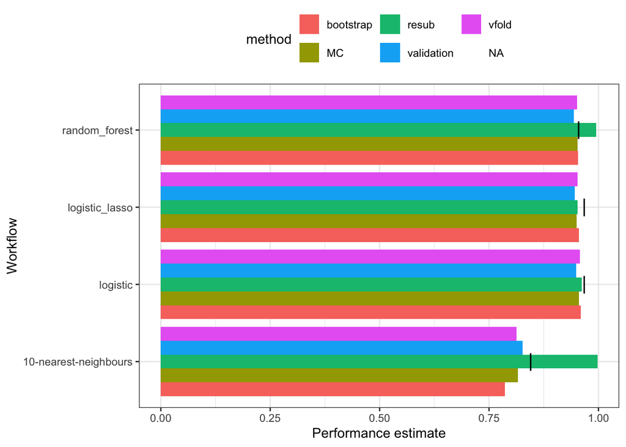

```r
ggplot(data = merged_data, aes(x = estimate, y = work_names, fill=method)) +
  geom_bar(stat = "identity", position = "dodge") +
  geom_point(data = roc_auc_all, aes(x = estimate, y = work_names), shape = "|", size = 5, show.legend = FALSE) +
  labs(x = "Performance estimate",
       y = "Workflow") +
  theme(legend.position = "top")
```

Which validation methods seemed to do a good job on estimating performance on the test set? Which ones did poorly?